# Pharmacological fMRI experiment

Project: Pharmacological fMRI experiment conducted on healthy human volunteers.

Abstract: In this experiment that I designed and led between 2019-2022, we examined how a targeted pharmacological manipulation of learning would impact pain perception and their brain correlates. Participants received either a placebo or a single 80 mg dose of d‐cycloserine (a partial NMDA receptor agonist) and underwent fMRI while receiving painful stimulations to the arm.

Data: This demo includes behavioral neuroscience, pharmacological, and neuroimaging (fMRI) data obtained from 50 human participants.

This project was published as: A randomized pharmacological fMRI trial investigating d‐cycloserine and brain plasticity mechanisms in learned pain responses.

Please note that this notebook contains only a small example from the analyses performed for this project. The purpose of this notebook is to demonstrate the thought process and types of analyses performed and is not exhaustive or complete. The full analyses performed for each project are reported in the published article.

## Load libraries and data

```r
# Load libraries
library(tidyr)
library(dplyr)
library(scales)
library(car)
library(reshape)
library(ggplot2)

# Suppress warnings
options(warn = -1)
```

```r
## import raw qualtrics file
dataPIPLE = read.csv("/Users/miat./Documents/OtherWork/Jobs-Grants/Portfolio/Jupyter/NeurofMRI/MainDataSheetPIPLE.csv",
                     stringsAsFactors = TRUE)
```

## Cleaning

```r
###### Start Cleaning ######

# Remove unnecessary columns
dataPIPLE <- subset(dataPIPLE, select = -c(SideEffects))

# have a look at the data
levels(dataPIPLE$Drug)
table(dataPIPLE$Age)

# rename variables
names(dataPIPLE)[names(dataPIPLE) == "Femaleis1"] <- "Gender"
names(dataPIPLE)[names(dataPIPLE) == "ColorPurpleis1"] <- "Color"
names(dataPIPLE)[names(dataPIPLE) == "DrugDCSis1"] <- "Drug"
names(dataPIPLE)[names(dataPIPLE) == "RightHandedis1"] <- "Hand"

# fix (reorder and rename) factors
dataPIPLE$Handed = factor(dataPIPLE$Hand,
                          levels = c("R",
                                     "L"),
                          labels = c("Ri",
                                     "Le" ))
# check that it's right
table(dataPIPLE$Handed)

# now you can delete the old variable
dataPIPLE <- subset(dataPIPLE, select = -c(Hand))
```

1. 'DCS'

2. 'Placebo'

```
18 19 20 21 22 23 24 25 26 27 28 29 32 35
 2  3  7  4 11  8  5  2  2  1  2  1  1  1
```

```
Ri Le
47  3
```

## Summary statistics

```r
# write the final clean dataframe
dataPIPLEfin = dataPIPLE


# have a look at the data
table(dataPIPLEfin$Age)

table(dataPIPLEfin$Drug)

table(dataPIPLEfin$Color)
```

```
18 19 20 21 22 23 24 25 26 27 28 29 32 35
 2  3  7  4 11  8  5  2  2  1  2  1  1  1
```

```
    DCS Placebo
     23      27
```

```
Purple Yellow
    25     25
```

```r
# correlations / additivity
correlALL = cor(dataPIPLEfin[ , c("Age",
                          "PainThresh",
                         "MeanLearnPre",
                         "MeanLearnPost",
                         "MeanPrecondDIFF",
                         "MeanBaseDIFF",
                         "MeanInduDIFF",
                         "EvoDIFFNt2minCt1",
                         "MeanEvo5DIFF")])
symnum(correlALL)
correlALL
```

```
                 A P MnLrnPr MnLrnPs MP MB MI E ME
Age              1
PainThresh         1
MeanLearnPre         1
MeanLearnPost        .       1
MeanPrecondDIFF                      1
MeanBaseDIFF         .               .  1
MeanInduDIFF                         .  ,  1
EvoDIFFNt2minCt1                     .  .  .  1
MeanEvo5DIFF                         .     .  , 1
attr(,"legend")
[1] 0 ‘ ’ 0.3 ‘.’ 0.6 ‘,’ 0.8 ‘+’ 0.9 ‘*’ 0.95 ‘B’ 1
```

A matrix: 9 × 9 of type dbl

|  | Age | PainThresh | MeanLearnPre | MeanLearnPost | MeanPrecondDIFF | MeanBaseDIFF | MeanInduDIFF | EvoDIFFNt2minCt1 | MeanEvo5DIFF |
| --- | --- | --- | --- | --- | --- | --- | --- | --- | --- |
| Age | 1.00000000 | 0.19253261 | -0.282738562 | -0.24780677 | -0.1541624 | -0.24850302 | -0.2469855 | -0.10392712 | -0.079115461 |
| PainThresh | 0.19253261 | 1.00000000 | 0.008180890 | 0.03320425 | -0.2099208 | -0.02346972 | -0.1204206 | -0.19031866 | -0.249542458 |
| MeanLearnPre | -0.28273856 | 0.00818089 | 1.000000000 | 0.55994002 | 0.1418028 | 0.32647444 | 0.2254238 | 0.09371374 | 0.001986195 |
| MeanLearnPost | -0.24780677 | 0.03320425 | 0.559940017 | 1.00000000 | 0.1749835 | 0.29447037 | 0.2202488 | 0.19628274 | -0.030987431 |
| MeanPrecondDIFF | -0.15416235 | -0.20992083 | 0.141802809 | 0.17498352 | 1.0000000 | 0.36994192 | 0.4653087 | 0.40733889 | 0.346262869 |
| MeanBaseDIFF | -0.24850302 | -0.02346972 | 0.326474439 | 0.29447037 | 0.3699419 | 1.00000000 | 0.6966733 | 0.42138010 | 0.193761058 |
| MeanInduDIFF | -0.24698552 | -0.12042057 | 0.225423787 | 0.22024884 | 0.4653087 | 0.69667331 | 1.0000000 | 0.56076225 | 0.416219843 |
| EvoDIFFNt2minCt1 | -0.10392712 | -0.19031866 | 0.093713739 | 0.19628274 | 0.4073389 | 0.42138010 | 0.5607622 | 1.00000000 | 0.639093845 |
| MeanEvo5DIFF | -0.07911546 | -0.24954246 | 0.001986195 | -0.03098743 | 0.3462629 | 0.19376106 | 0.4162198 | 0.63909384 | 1.000000000 |

```r
# crosstabulate some bivariate stuff
table(dataPIPLEfin$Drug, dataPIPLEfin$Gender)
```

```
           F  M
  DCS     20  3
  Placebo 19  8
```

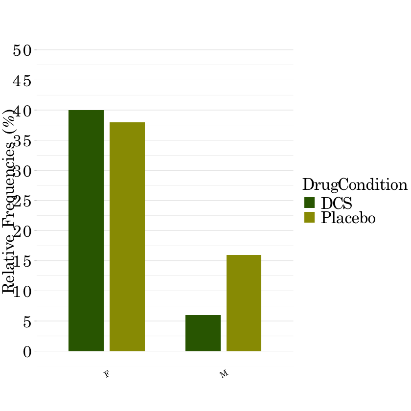

```r
# Plot CATEGORICALS
ggplot(dataPIPLEfin, aes(x = Gender, fill = Drug)) +
  geom_bar( aes(y = (..count..)/sum(..count..) *100 ), size=2, width=0.6, position = position_dodge(0.7)) +
  scale_fill_manual(name="DrugCondition", values=c("#336600", "#999900")) +
  theme_light() +
  theme(
    plot.title = element_text(color = "black",
                              size = 20,
                              face = "bold",
                              lineheight = 0.9,
                              hjust = 0,
                              family="AppleMyungjo"),
    plot.subtitle = element_text(size = 20,
                                 family="AppleMyungjo"),
    plot.caption = element_text(size = 20,
                                face = "bold",
                                lineheight = 0.9,
                                hjust = 0,
                                vjust = 0,
                                family="AppleMyungjo"),
    panel.grid.major.x = element_blank(),
    panel.border = element_blank(),
    axis.ticks.x = element_blank(),
    axis.text.x = element_text( angle = 30,
                                color="black",
                                size=10,
                                face=1,
                                hjust = 0.55,
                                vjust = 0.75,
                                family="AppleMyungjo"),
    axis.text.y = element_text( angle = 0,
                                color="black",
                                size = 20,
                                face=1,
                                family="AppleMyungjo"),
    axis.title.y.left = element_text( angle = 90,
                                      color="black",
                                      size = 20,
                                      face=2,
                                      family="AppleMyungjo"),
    axis.title.x.bottom = element_text( angle = 0,
                                        color="black",
                                        size = 20,
                                        face=3,
                                        family="AppleMyungjo"),
    legend.position = "right",
    legend.justification = c("right", "center"),
    legend.box.just = "top",
    legend.margin = margin(0.2, 0.2, 0.2, 0.2),
    legend.title = element_text(color = "Black",
                                size = 20,
                                family="AppleMyungjo"),
    legend.text = element_text(color = "Black",
                               size = 20,
                               family="AppleMyungjo"),
    plot.margin = margin(0.1,0.1,0.1,0.1, "cm"),
  ) +
  scale_y_continuous(limits = c(0,50), breaks = scales::pretty_breaks(n = 10)) +
  xlab("") +
  ylab("Relative Frequencies (%)") +
  labs(title = "",
       subtitle = "",
       caption = "")
```

## EDA and Inferential Statistics

```r
# Make a master set
master = dataPIPLEfin
```

```r
#### START for rmANOVA for nocebo manipulation check ###########

# make long data for 1st trials
longpre = subset(master, select = c(Subject,EvoC1, EvoN2))

longdata = melt(longpre,
                id = "Subject",
                measured = c("EvoC1", "EvoN2"))
colnames(longdata) = c("Subject", "TRIALTYPE", "PAINRATING")
```

13.8155105579643

2

[output not shown]

```
   Mode    TRUE
logical     100
```

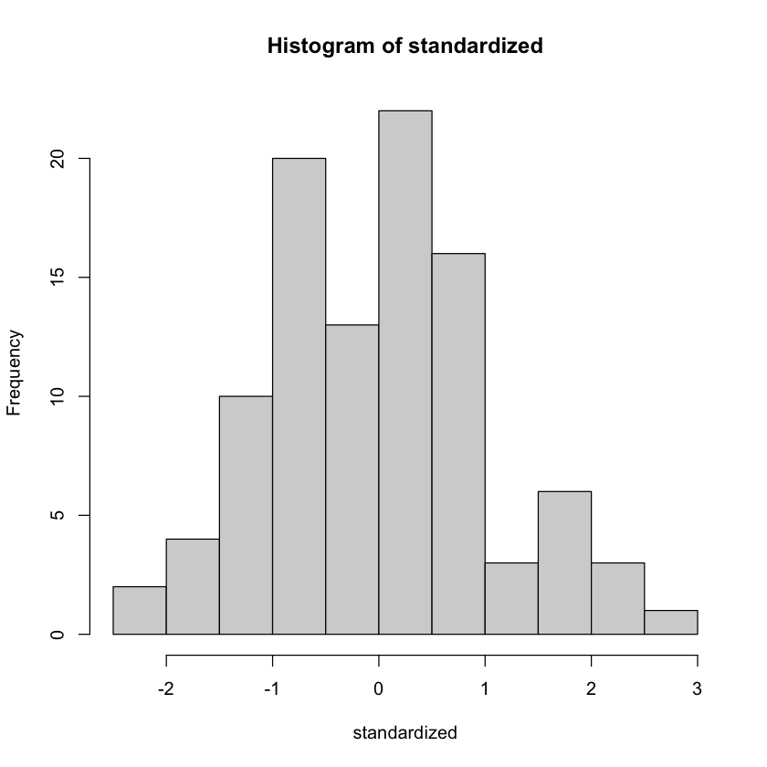

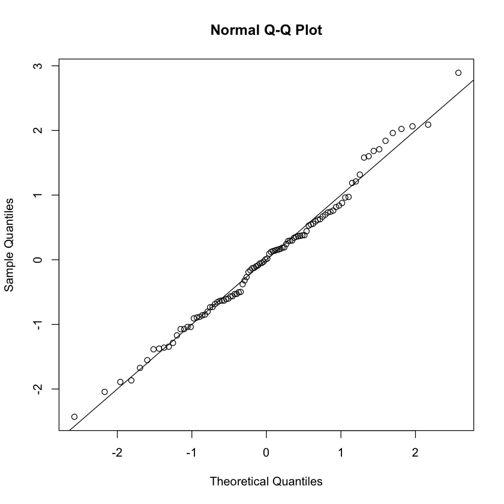

A anova: 2 × 3

|  | Df <int> | F value <dbl> | Pr(>F) <dbl> |
| --- | --- | --- | --- |
| group | 1 | 3.634383e-06 | 0.9984828 |
|  | 98 | NA | NA |

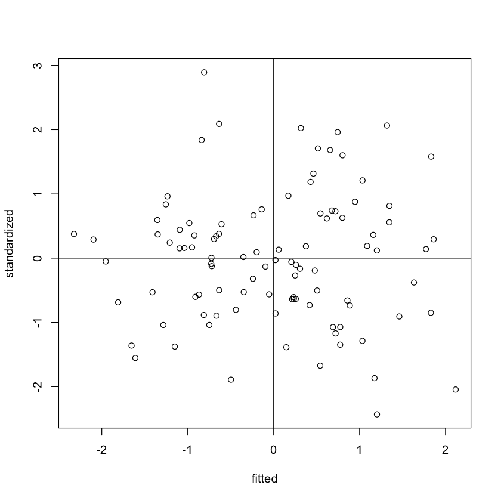

```r
# outliers
cutoff = qchisq(1-.001, ncol(longdata[ , c(1, 3)]))
mahal = mahalanobis(longdata[ , c(1, 3)],
                    colMeans(longdata[ , c(1, 3)], na.rm = T),
                    cov(longdata[ , c(1, 3)], use = "pairwise.complete.obs"))
cutoff ##cut off score
ncol(longdata[ , c(1, 3)]) ##df
table(mahal) #take a look
summary(mahal < cutoff) ##number of outliers
longdata = subset(longdata, mahal < cutoff) ##exclude outliers

# assumption check set up
random = rchisq(nrow(longdata), 7)
fake = lm(random~., data = longdata)
standardized = rstudent(fake)
fitted = scale(fake$fitted.values)

# normality
hist(standardized)

# linearity
qqnorm(standardized)
abline(0,1)

# homog + s
plot(fitted,standardized)
abline(0,0)
abline(v=0)

# Levene's test is NON-SIGNIFICANT
leveneTest(PAINRATING ~ TRIALTYPE,
           data = longdata, center = mean)
```

# fMRI data (ROI results)

```r
## Load data that includes fMRI parameters
datafMRI = read.csv("/Users/miat./Documents/OtherWork/Jobs-Grants/Portfolio/Jupyter/NeurofMRI/PIPLEparametersForR.csv",
                    stringsAsFactors = TRUE)
```

## Cleaning

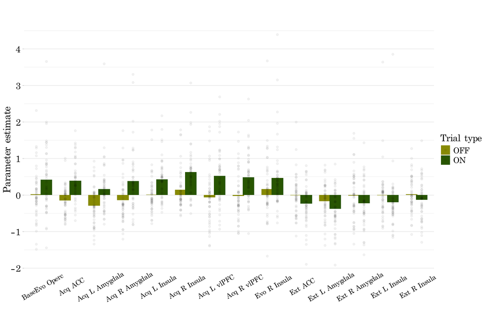

```r
# Fix (reorder and rename) the factors

datafMRI$PhaseRegion = factor(datafMRI$PhaseRegion,
                          levels = c("BaseEvo Operc",
                                     "Acq ACC",
                                     "Acq L Amygdala",
                                     "Acq R Amygdala",
                                     "Acq L Insula",
                                     "Acq R Insula",
                                     "Acq L vlPFC",
                                     "Acq R vlPFC",
                                     "Evo R Insula",
                                     "Ext ACC",
                                     "Ext L Amygdala",
                                     "Ext R Amygdala",
                                     "Ext L Insula",
                                     "Ext R Insula"),
                          labels = c("BaseEvo Operc",
                                     "Acq ACC",
                                     "Acq L Amygdala",
                                     "Acq R Amygdala",
                                     "Acq L Insula",
                                     "Acq R Insula",
                                     "Acq L vlPFC",
                                     "Acq R vlPFC",
                                     "Evo R Insula",
                                     "Ext ACC",
                                     "Ext L Amygdala",
                                     "Ext R Amygdala",
                                     "Ext L Insula",
                                     "Ext R Insula"))

# PLOT roi parameter estimates fMRI
options(repr.plot.width=12, repr.plot.height=8)

ggplot(datafMRI, aes(PhaseRegion, Estimate, fill = Trial.or.on.is.evo)) +
  stat_summary(fun.data = mean_sdl,
               geom = "errorbar",
               color= "grey",
               position = position_dodge(width = 0.70),
               width = 0.3
               #, ymin=0) +
                            ) +
  stat_summary(fun = mean,
               geom = "bar",
               position = position_dodge(width = 0.70),
               width = 0.8) +
  geom_point(alpha=0.05,
             aes(fill= Trial.or.on.is.evo),
             position = position_dodge(width = 0.70)) +
  scale_fill_manual(name="Trial type", values=c("#999900", "#336600")) +
  theme_light() +
  theme(
    plot.title = element_text(color = "black",
                              size = 11,
                              face = "bold",
                              lineheight = 0.2,
                              hjust = 0,
                              family="AppleMyungjo"),
    plot.subtitle = element_text(size = 11,
                                 family="AppleMyungjo"),
    plot.caption = element_text(size = 16,
                                face = "bold",
                                lineheight = 0.2,
                                hjust = 0,
                                vjust = 0,
                                family="AppleMyungjo"),
    panel.grid.major.x = element_blank(),
    panel.border = element_blank(),
    axis.ticks.x = element_blank(),
    axis.text.x = element_text( angle = 30,
                                color="black",
                                size=12,
                                face=1,
                                hjust=0.5,
                                vjust=0.95,
                                family="AppleMyungjo"),
    axis.text.y = element_text( angle = 0,
                                color="black",
                                size=16,
                                face=1,
                                family="AppleMyungjo"),
    axis.title.y.left = element_text( angle = 90,
                                      color="black",
                                      size=17,
                                      face=2,
                                      family="AppleMyungjo"),
    axis.title.x.bottom = element_text( angle = 0,
                                        color="black",
                                        size=14,
                                        face=3,
                                        family="AppleMyungjo"),
    legend.position = "right",
    legend.justification = c("right", "center"),
    legend.box.just = "top",
    legend.margin = margin(0.2, 0.2, 0.2, 0.2),
    legend.title = element_text(color = "Black",
                                size = 16,
                                family="AppleMyungjo"),
    legend.text = element_text(color = "Black",
                               size = 14,
                               family="AppleMyungjo"),
    plot.margin = margin(0.2,0.8,0.2,0.2, "cm")
  ) +
  scale_y_continuous(limits = c(-2,4.5), breaks = scales::pretty_breaks(n = 10)) +
  xlab("") +
  ylab("Parameter estimate") +
  labs(title = "",
       subtitle = "",
       caption = "")
```

# Conclusions

One interesting result of this analysis was that there were increased activations bilaterally in the amygdala, ACC, and insula, during pain trials compared to control trials. The results overall supported the involvement of integrative cognitive‐emotional processes in learned pain effects.

Please note that this notebook contains only a small example from the analyses performed for this project. The purpose of this notebook is to demonstrate the thought process and types of analyses performed and is not exhaustive or complete. The full analyses performed for each project are reported in the published article.

Dr. Mia Thomaidou (2024)